# Missing data summary

Matt T

2021-08-05

### Model

Then used an AR(1) missing data process-model with an intercept and light covariate to model the parameters and missing data.
$$GPP=\beta_0+\phi\times GPP_{t-1}+\beta_1\times X_{light}+\epsilon_{sdp}$$
### Bias Calculation
Then used an AR(1) missing data process-model with an intercept and light covariate to model the parameters and missing data.
$$Bias= Parameter_{known}-Mean \; Parameter_{estimated}$$
### Relative Width of Credible Interval (RWCI)
The relative width of the credible interval can show how the change in the credible interval with increasing missing data relative to the complete data.

$$RWCI= log\left(\frac{Upper\: CI_{estimated}- Lower\:CI_{estimated}} {Upper\: CI_{complete}- Lower\:CI_{complete}}\right)$$
where: Upper CI = 97.5% quantile of posterior distribution Lower CI = 2.5% quantile of posterior distribution Estimated= quantiles estimated from dataset with missing data Complete= quantiles estimated from complete dataset

### Stan Code

```r
"

/*----------------------- Data --------------------------*/
  /* Data block: defines the objects that will be inputted as data */
  data {
    int N; // Length of state and observation time series
    vector[N] y_miss; // Observations
    real z0; // Initial state value
    vector[N] light; //log of light observations
    int y_nMiss; // number of missing values
    int y_index_mis[y_nMiss]; // index or location of missing values within the dataset
  }



/*----------------------- Parameters --------------------------*/
  /* Parameter block: defines the variables that will be sampled */
  parameters {
    vector<lower = 0>[y_nMiss] y_imp;// Missing data
    real<lower=0> sdp; // Standard deviation of the process equation
    real b0;
    real b1;
    real<lower = 0, upper=1 > phi; // Auto-regressive parameter

  }
  transformed parameters {
    vector[N] y;
    y=y_miss; // makes the data a transformed variable
    y[y_index_mis] =y_imp; // replaces missing data in y with estimated data
  }



  /*----------------------- Model --------------------------*/
  /* Model block: defines the model */
  model {
    // Prior distributions
    sdp ~ normal(0, 1);
    phi ~ beta(1,1);
    b0 ~ normal(0,5);
    b1 ~ normal(0,5);

    // Distribution for the first value
    y[1] ~ normal(z0, sdp);

    // Distributions for all other states
    for(t in 2:N){
      y[t] ~ normal(b0+y[t-1]*phi+light[t]*b1, sdp);
    }


  /*----------------------- Generated Quantities --------------------------*/
  /*Generated Quantities block: genereate things, such as modeled estimates for PPC */
   generated quantities {
    vector[N] y_rep; // replications from posterior predictive dist
    y_rep[1]=normal_rng(y[1], 0.1);

    for (t in 2:N) {
    y_rep[t]=normal_rng(b0+y[t-1]*phi+light[t]*b1, sdp);
 }
  }
"
```

### Simulated-randomly missing days-high error and phi

$$GPP=\beta_0+\phi\times GPP_{t-1}+\beta_1\times X_{light}+\epsilon_{sdp}$$
$\beta_0$=0.1
$\epsilon_{sdp}$= 0.1
$\phi$=0.8
$\beta_1$=0.1
$X_{light}$=modeled from Yard et al. (1995) Ecological Modeling

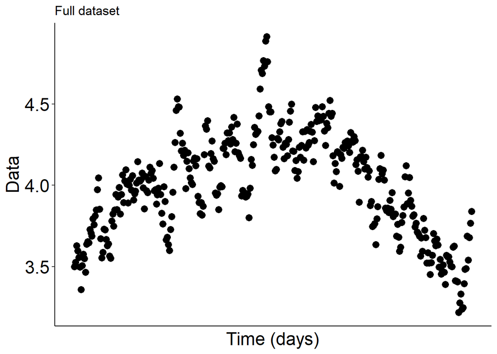

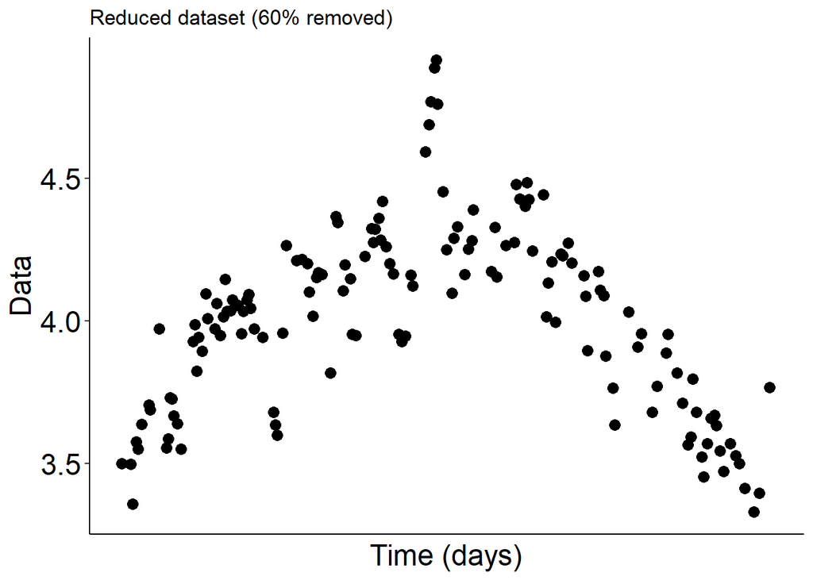

### Bayes estimated missing data-simulated missing days-high sdp (0.1) and phi (0.8)

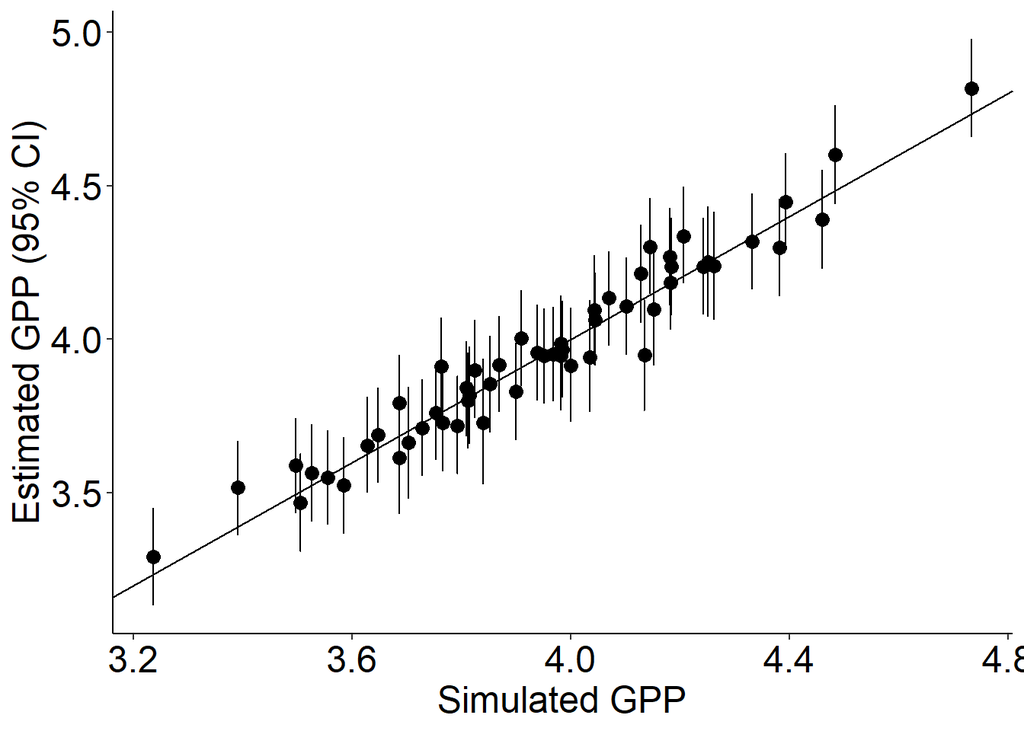

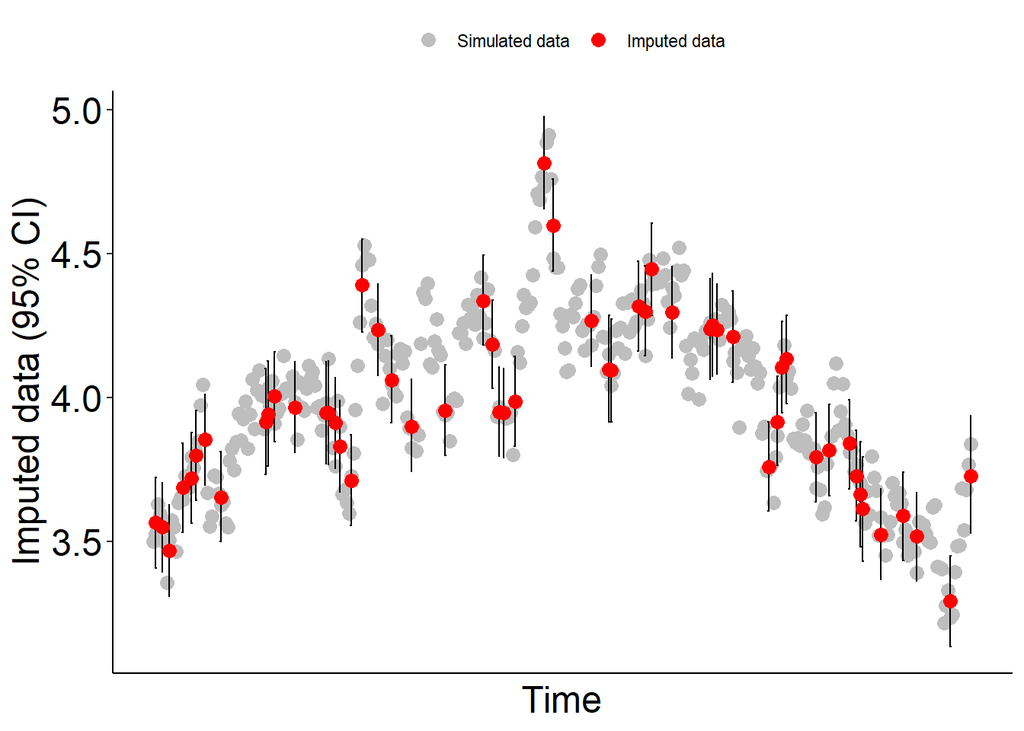

[figure not shown]

### Bayes parameter-simulated missing days-high sdp (0.1) and phi (0.8)

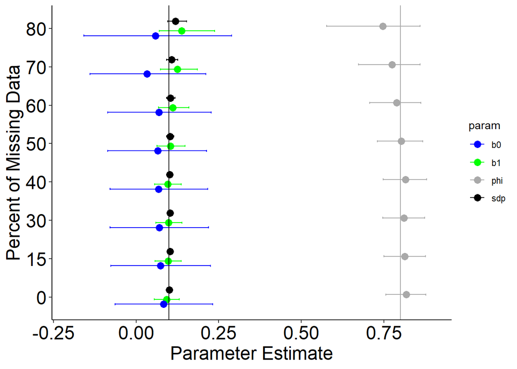

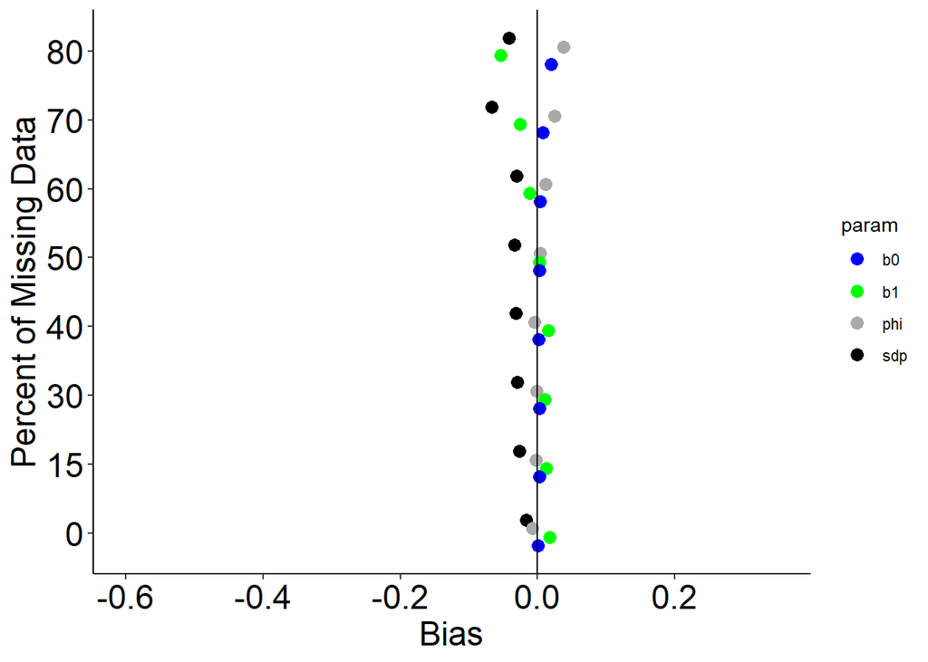

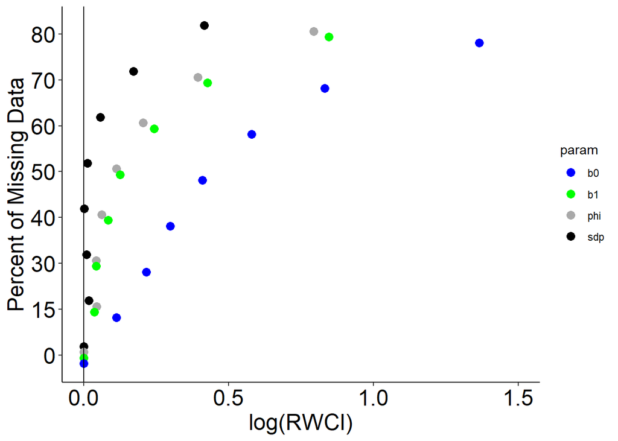

### Amelia estimated missing data-simulated missing days

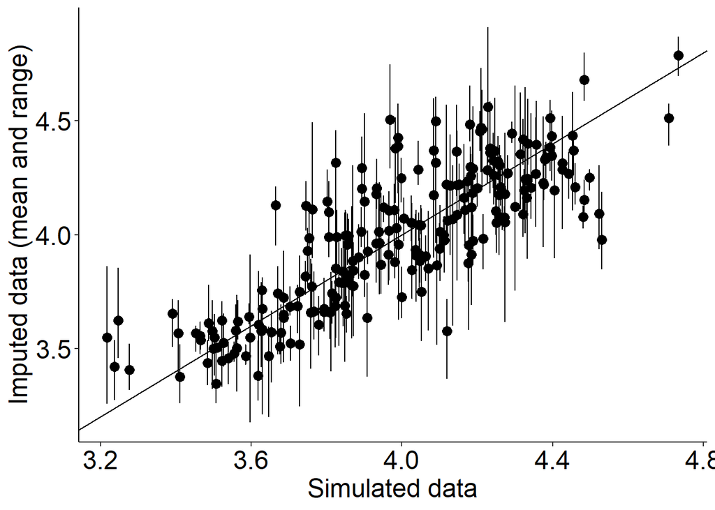

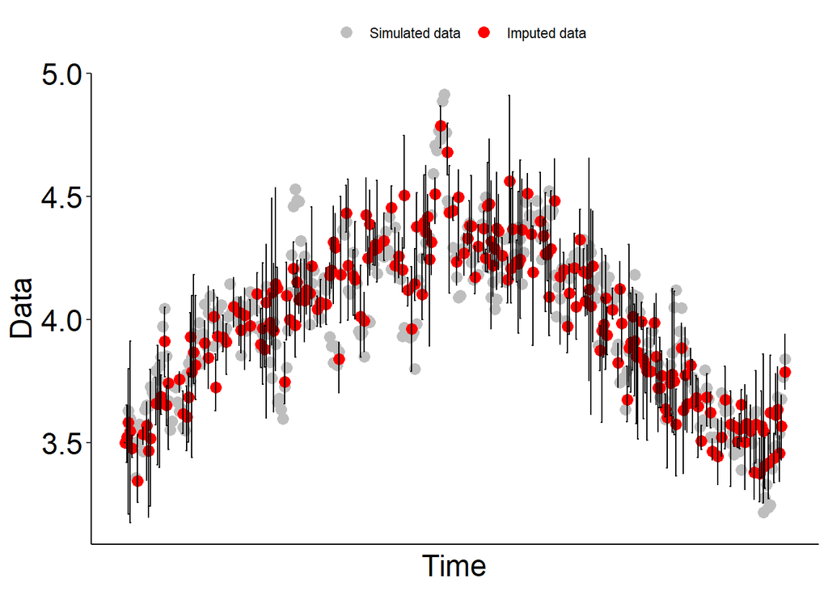

### Amelia parameter-simulated missing days sdp=0.1, phi=0.8

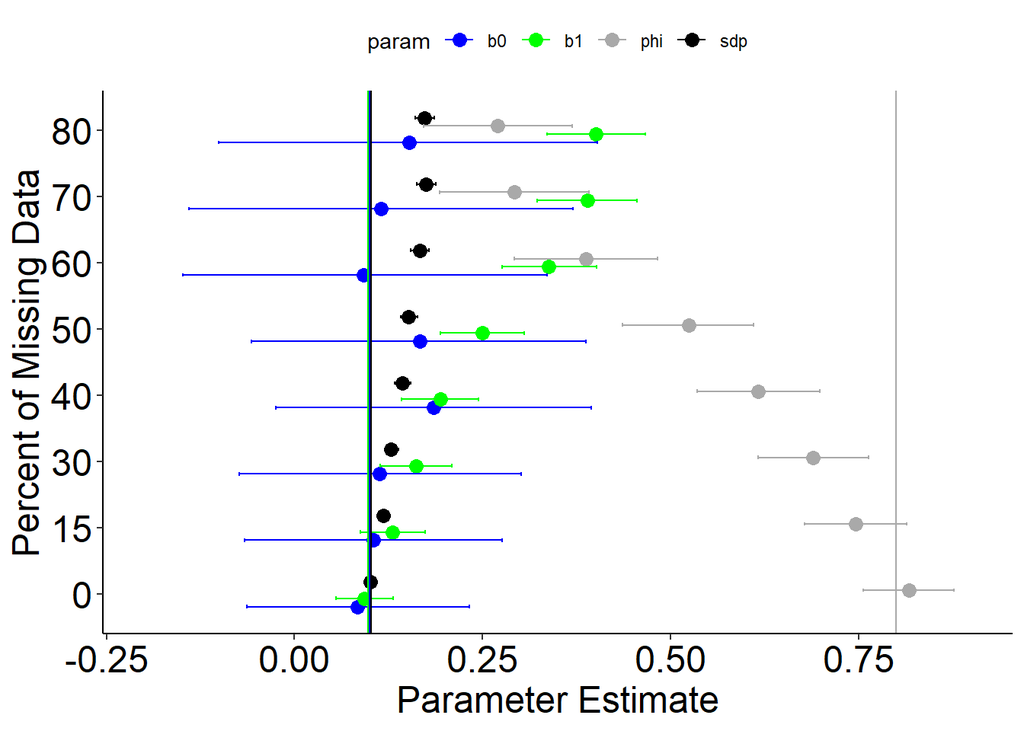

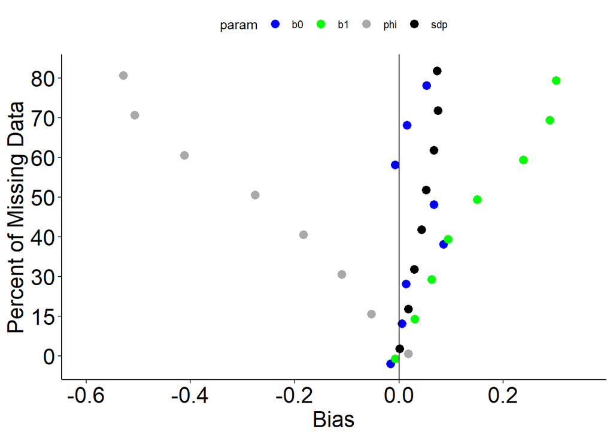

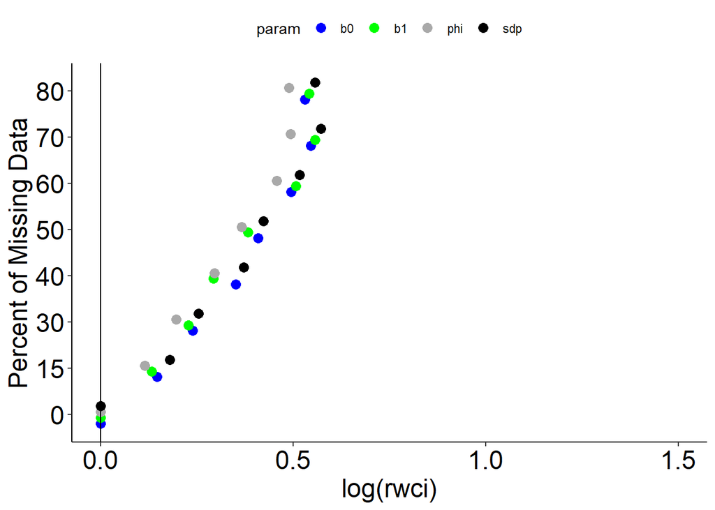

### Simulated-randomly missing days-lower error

$$GPP=\beta_0+\phi\times GPP_{t-1}+\beta_1\times X_{light}+\epsilon_{sdp}$$
$\beta_0$=0.1
$\epsilon_{sdp}$= 0.01
$\phi$=0.8
$\beta_1$=0.1
$X_{light}$=modeled from Yard et al. (1995) Ecological Modeling

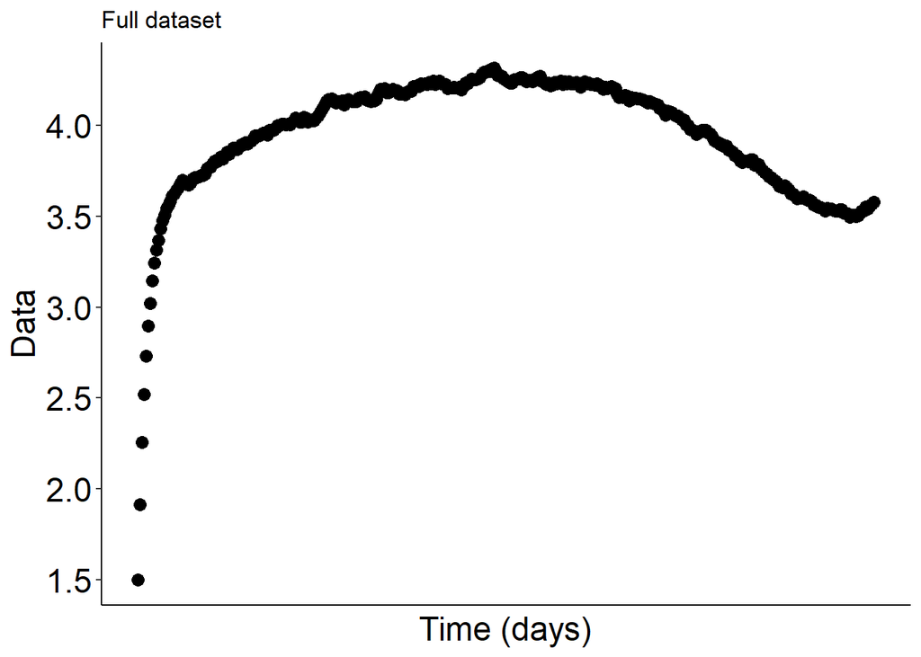

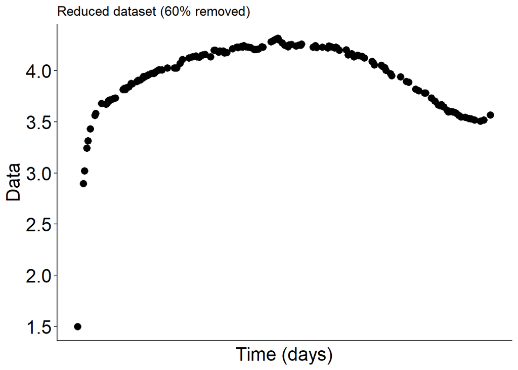

### Bayes estimated missing data-simulated missing days-sdp=0.01, phi= 0.8

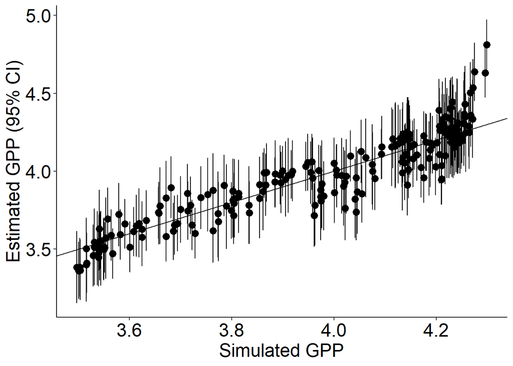

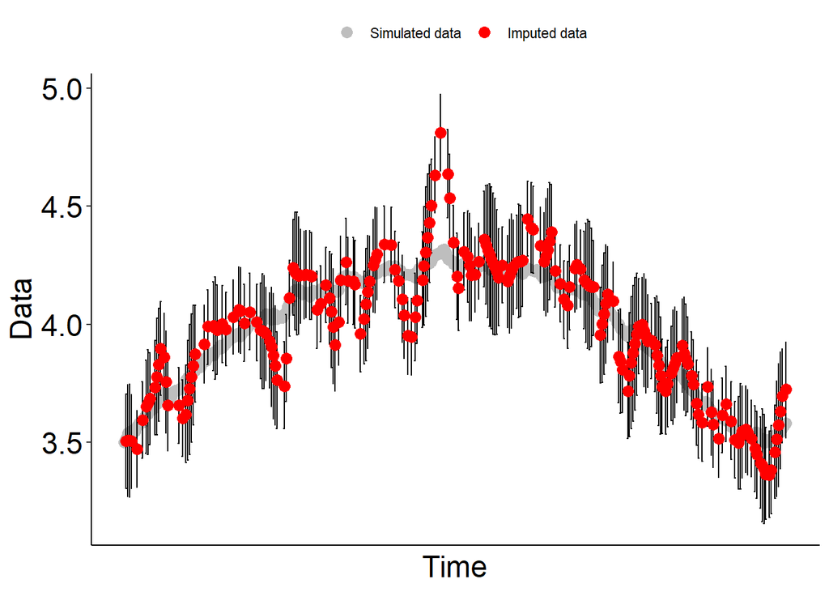

### Bayes parameter-simulated missing days sdp=0.01, phi=0.8

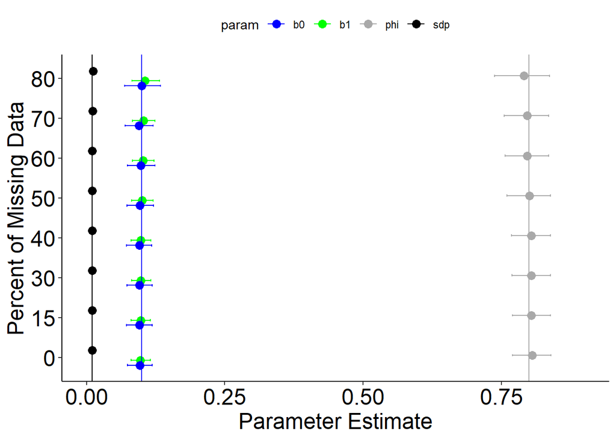

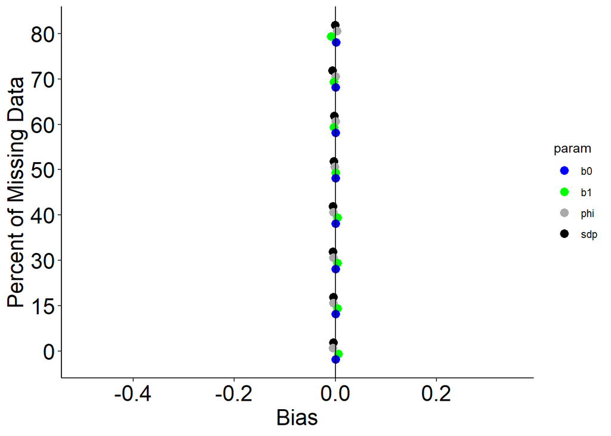

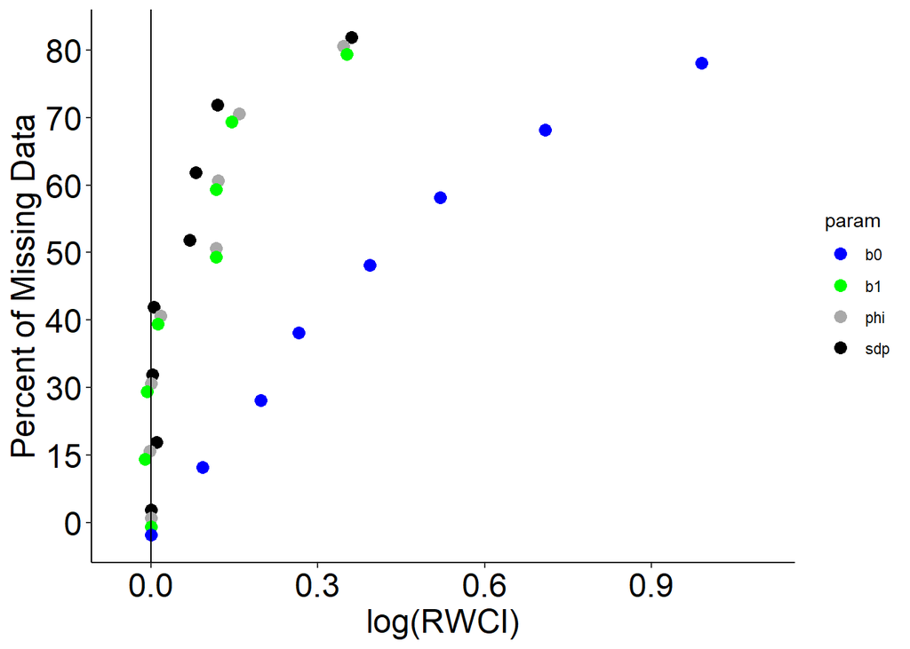

### Amelia parameter-simulated missing days sdp=0.01, phi=0.8

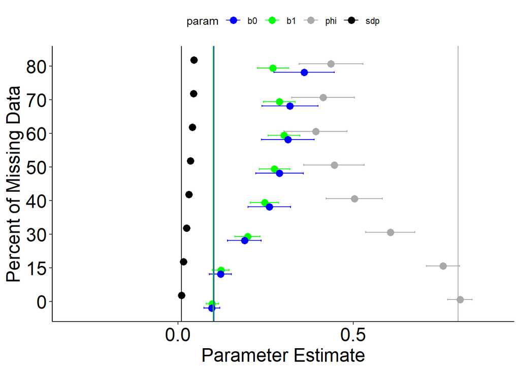

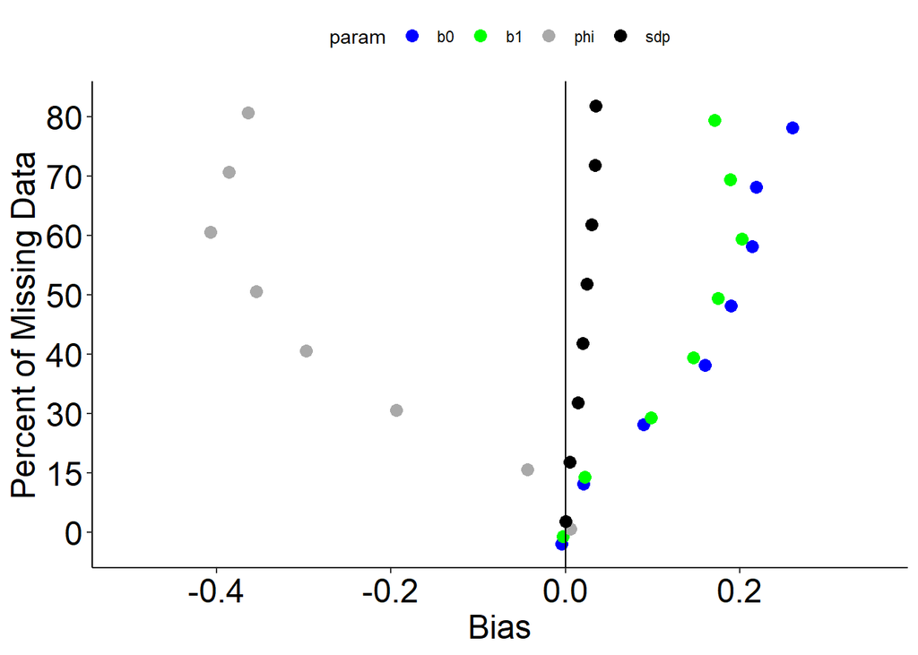

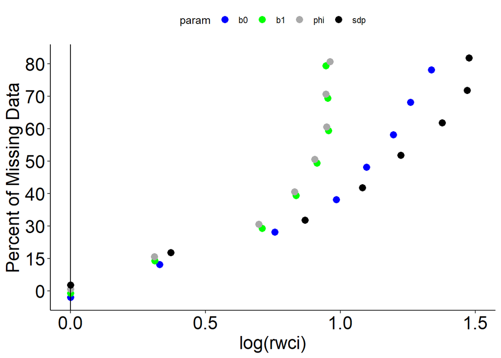

[output not shown]

[figure not shown]

[figure not shown]

[figure not shown]

### Simulated-randomly missing weeks

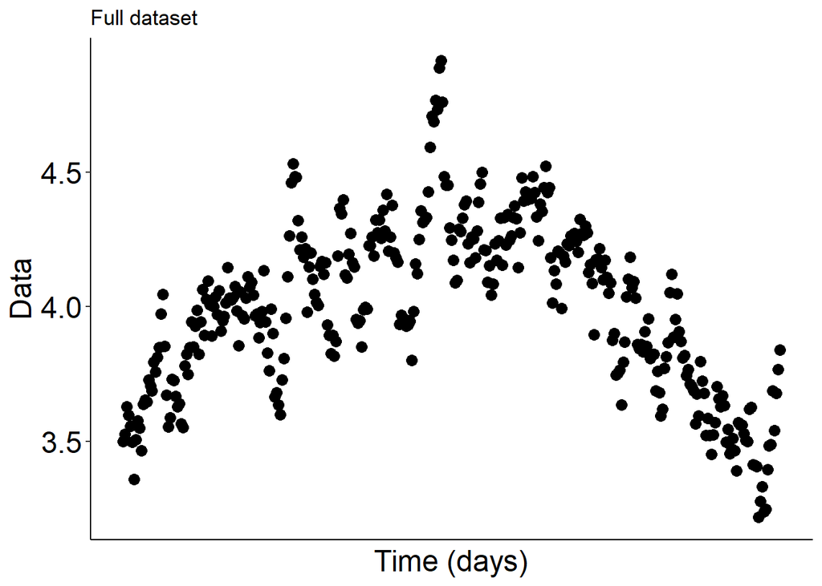

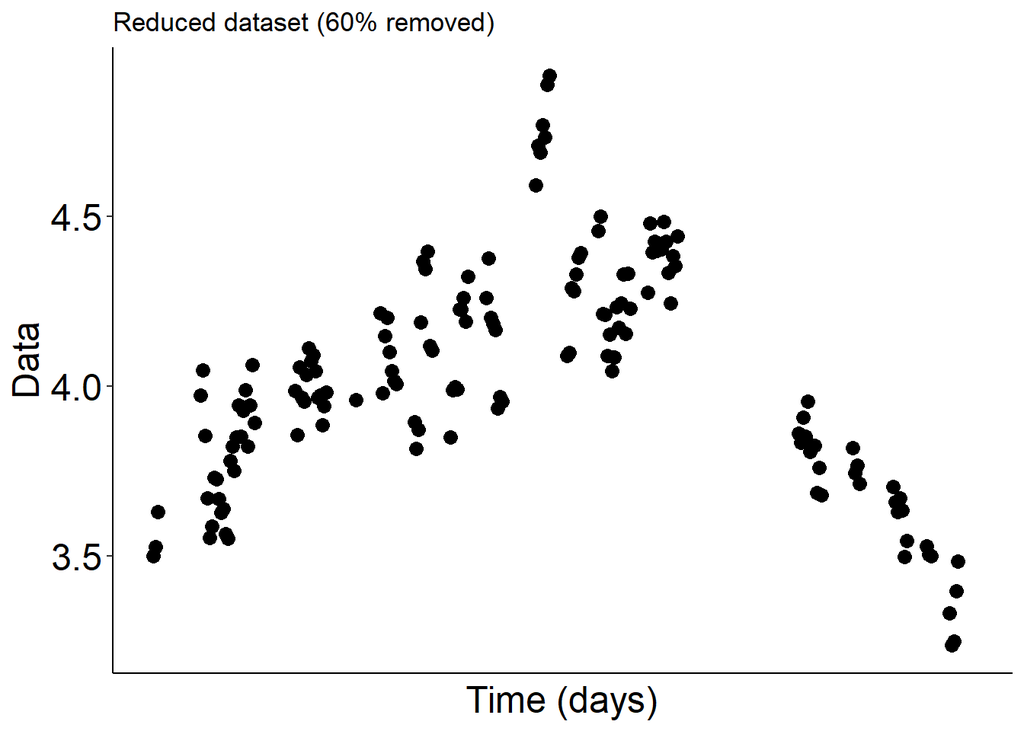

### Bayes estimated missing data simulated missing weeks-higher sdp and phi

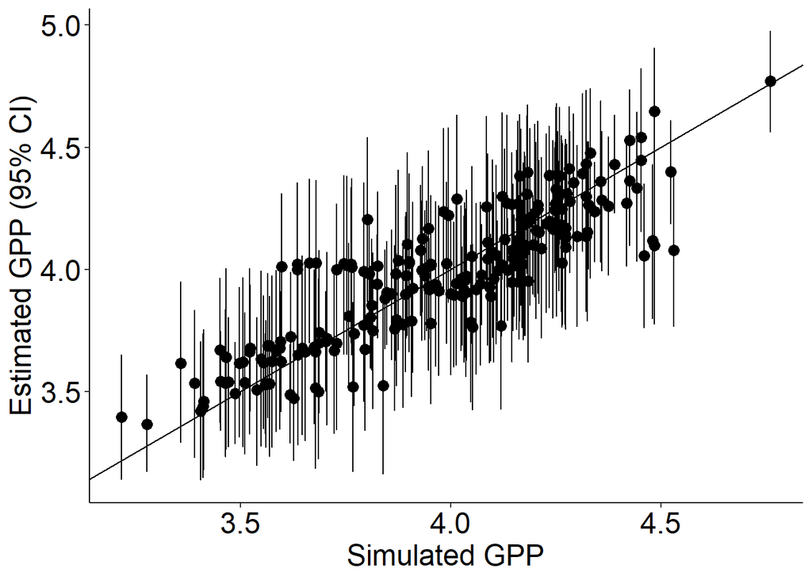

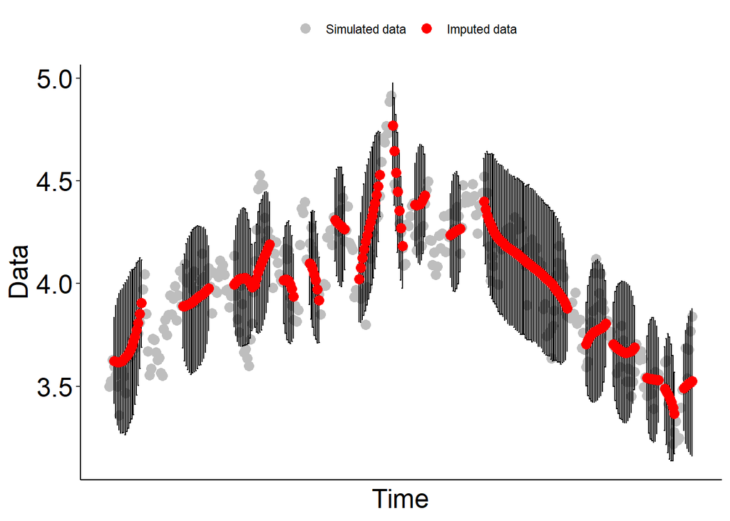

### Bayes parameter-simulated missing weeks

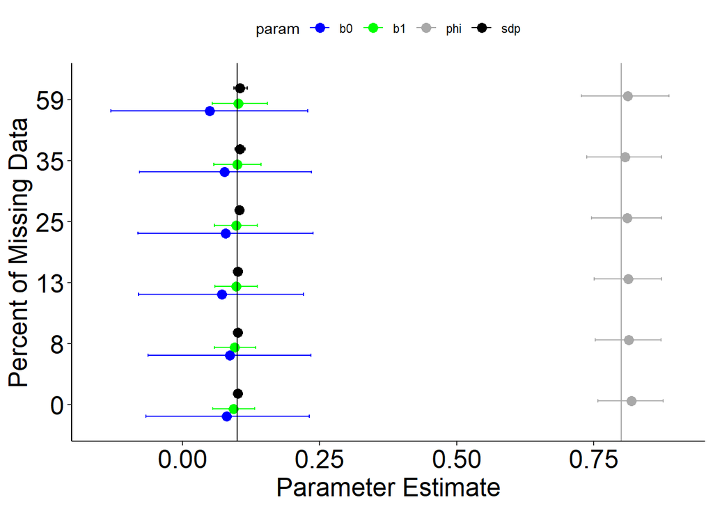

### Missing data in the context of Shatto Ditch and Kalamath datasets

| Site | Years of data | Missing data (%) | Average length (d) | St. dev (d) |
| --- | --- | --- | --- | --- |
| Shatto | 10 | 40.1 | 8.7 | 21.6 |
| SV | 3 | 3.8 | 2.5 | 2.3 |

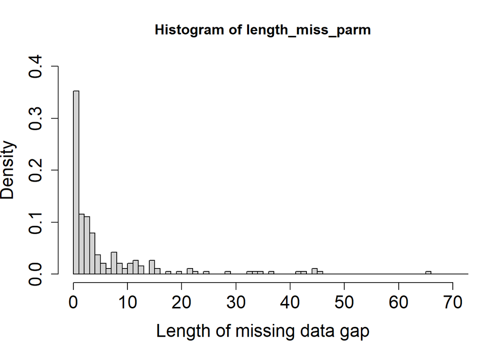

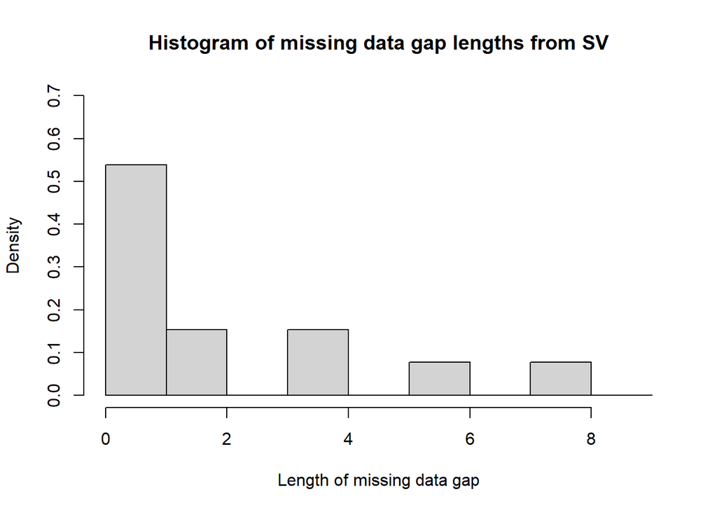